# Relatório

Victor Lucas Santana

# 1 Introdução

O objetivo desse trabalho é produzir um relatório aplicando técnicas de estatística univariada e bivariada. O arquivo de dados que será analisado foi gerado a partir dos microdados da PNS2019 no estado de Goiás (UF 52).

# 2 Análises

## 2.1 Associação entre o tipo de situação censitária(V0026) e acesso à internet no domicílio(A01901).

O foco desa análise é verificar como o comportamento da variável resposta Y (Acesso à internet no domicílio) muda na presença da variável explicativa X (Tipo de situação censitária). A hipótese inicial é de que moradores da área urbana tenham mais acesso à internet do que moradores da área rural.

Com a tabela de frequencias absolutas é possível observar que o maior número de domicílios com acesso à internet se encontra no meio urbano.

Frequencias absolutas

|  | Com Internet | Sem Internet |
| --- | --- | --- |
| Urbano | 1225 | 101 |
| Rural | 163 | 92 |

Com a tabela de frequencias relativas observa-se que os valores em cada categoria da variável resposta não são os mesmos para os diferentes níveis da variável explicativa, logo as frequências relativas dos diferentes níveis de Y dependem dos níveis de X.

Frequencias Relativas

|  | Com Internet | Sem Internet |
| --- | --- | --- |
| Urbano | 0.77 | 0.06 |
| Rural | 0.10 | 0.06 |

Para responder se existe relação de dependencia entre o acesso à internet e o tipo de situação censitária verifica-se a distribuição de Y condicionada a X.

```
##        Com Internet Sem Internet Sum
## Urbano         0.92         0.08   1
## Rural          0.64         0.36   1
##                0.88         0.12   1
```

Se o tipo de situação censitária não influenciasse no acesso à internet, esperaríamos ver as proporções da ultima linha linha da tabela para os níves Urbano e Rural. Também é possível verificar graficamente.

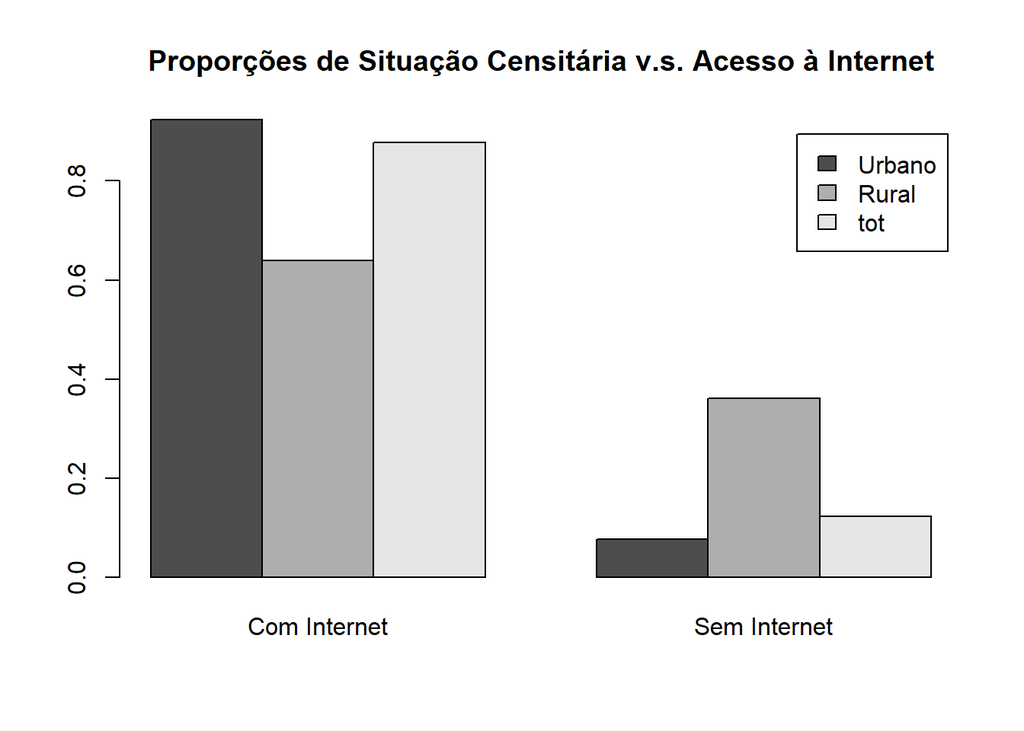

Realizando o teste Qui-quadrado é possível rejeitar a hipótese H0 (de que as variáveis são independendes), uma vez que o valor de p é menor do que 0,05, aceitando então a hipótese de associação entre as variáveis.

```
##
##  Pearson's Chi-squared test with Yates' continuity correction
##
## data:  qui
## X-squared = 159.01, df = 1, p-value < 0.00000000000000022
```

Dessa maneira, confirma-se como verdadeira a hipótese inicial dessa análise, de fato o acesso á internet depende do tipo de situação censitária, de tal forma que os moradores do meio urbano tem mais acesso à internet do que os moradores do meio rural.

## 2.2 Associação entre a prática de algum exercício físico ou esporte nos últimos 3 meses(P034) e a percepção da própria qualidade do estado de saúde(N001).

O foco desa análise é verificar como o comportamento da variável resposta Y (qualidade de saúde) muda na presença da variável explicativa X (prática de exercício físico). A hipótese inicial é de que pessoas que tenham práticado algum tipo de atividade física nos últimos 3 meses sintam-se com uma melhor qualidade de saúde do que indivíduos que não tenham praticado essas atividades.

Com a tabela de frequencias absolutas é possível observar que a maioria dos indivíduos que relataram ter uma saúde ‘Muito Boa’ praticaram algum tipo de atividade física nos últimos 3 meses.

Frequencias Absolutas

|  | Muito Boa | Boa | Regular | Ruim | Muito Ruim |
| --- | --- | --- | --- | --- | --- |
| Praticantes | 198 | 395 | 119 | 12 | 3 |
| Não Praticantes | 118 | 450 | 242 | 36 | 8 |

Pela tabela de frequencias relativas nota-se que os valores das categorias da variável resposta são diferentes para cada nível da variável explicativa, portanto as frequências relativas dos níveis de Y dependem dos níveis de X.

Frequencias Relativas

|  | Muito Boa | Boa | Regular | Ruim | Muito Ruim |
| --- | --- | --- | --- | --- | --- |
| Praticantes | 0.13 | 0.25 | 0.08 | 0.01 | 0.00 |
| Não Praticantes | 0.07 | 0.28 | 0.15 | 0.02 | 0.01 |

Para responder se existe associação entre o a prática de atividade física e o tipo de qualidade de saúde verifica-se a distribuição de Y condicionada a X.

```
##                 Muito Boa  Boa Regular Ruim Muito Ruim Sum
## Praticantes          0.27 0.54    0.16 0.02       0.00   1
## Não Praticantes      0.14 0.53    0.28 0.04       0.01   1
##                      0.20 0.53    0.23 0.03       0.01   1
```

Se a prática de atividade física não influenciasse no nível de saúde, esperaríamos ver as proporções da ultima linha linha da tabela para os níves dos praticantes e dos não praticantes de atividades físicas. Também é possível verificar graficamente.

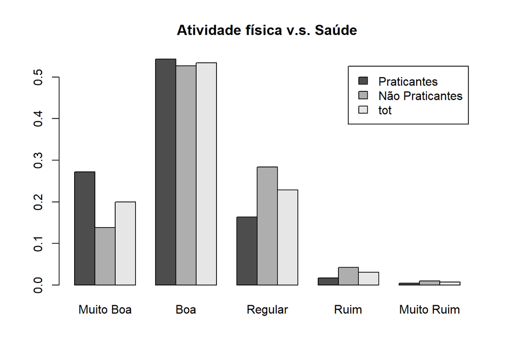

Realizando o teste Qui-quadrado é possível rejeitar a hipótese H0 (de que as variáveis são independendes), uma vez que o valor de p é menor do que 0,05, aceitando então a hipótese de associação entre as variáveis.

```
##
##  Pearson's Chi-squared test
##
## data:  qui
## X-squared = 70.266, df = 4, p-value = 0.00000000000001995
```

Com base nas análises, pode-se concluir que indivíduos que mais reportaram uma qualidade de saúde ‘Muito Boa’ praticaram atividades físicas nos últimos 3 meses, enquanto os que mais reportaram uma qualidade de saúde ‘Regular’, ‘Ruim’ e ‘Muito Ruim’, não praticaram atividades físicas, portanto a hipótese inicial da análise é verdadeira.

## 2.3 Associação entre saber ler e escrever(D001) e rendimento bruto mensal ou retirada que fazia no trabalho(E01602).

O foco desa análise é verificar como o comportamento da variável resposta Y (renda) muda na presença da variável explicativa X (saber ler e escrever). A hipótese inicial é de que pessoas que saibam ler e escrever tenham um salário superior à pessoas que não saibam.

Para investigar a relação entre a variável explicativa categórica e a variável resposta numérica, utiliza-se da análise de variâncias com o teste F, e o gráfico de médias com intervalo de confiança.

[figure not shown]

Ao análisar a variância por meio do gráfico acima, que leva em conta o intervalo de confiança (IC) para a média, nota-se que não há sobreposição, indicando dessa forma que não existem médias iguais.

Por meio do teste F (conjunto), através da Tabela da ANOVA (analysis of variance), que compara as variâncias, é possível testar se a distribuição está de acordo com a hipótese nula de que todos os grupos têm médias iguais (são de uma mesma distribuição).

Tabela Anova

|  | S.Q | G.L | M.Q | F | P_val |
| --- | --- | --- | --- | --- | --- |
| Entre | 45756342 | 1 | 45756342 | 7.0243 | 0.008 |
| Dentre | 10142360842 | 1557 | 6514040 |  |  |
| Total | 10188117184 | 1558 | 52270382 |  |  |

A hipótese a ser testada (H0) é que as médias de Y para cada categoria de X são todas iguais. A hipótese alternativa (HA) é: existe pelo menos uma média diferente. Calcula-se o valor tabelado.

```
## [1] 3.847438
```

Como a estatística do teste é maior do que o valor tabelado, rejeita-se a hipótese de igualdade de médias, consequentemente, aceitando a hipótese alternativa. Confirmando portanto a hipótese inicial dessa análise, de fato pessoas que sabem ler possuem um salário maior do que pessoas que não sabem ler.

## 2.4 Relação entre peso(P00104) e altura(P00404).

O foco dessa análise é investigar a relação entre a variável Y (peso) e a variável X (altura) e encontrar a reta de regressão linear para essa relação.

Para medir a direção e a intensidade da relação linear entre as duas variáveis, utiliza-se do coeficiente de correlação de Pearson. O Coeficiente de correlação de Pearson para as variáveis Altura (X) e Peso (Y) é:

Coeficiente de correlação de Pearson

| x |
| --- |
| 0.504 |

Demonstra uma relação positiva linear moderada, conforme uma variável aumenta, a outra também aumenta.

Além de se conhecer o grau de associação, é possível estabelecer uma equação para a relação das duas variáveis, a reta de regressão linear é a melhor reta que resume os dados num diagrama de dispersão.

Resultado do Ajuste de Regressão Linear

|  | Estimate | Std. Error | t value | Pr(>\|t\|) |
| --- | --- | --- | --- | --- |
| (Intercept) | -64.23 | 6.079 | -10.56 | 0 |
| altura | 0.83 | 0.036 | 23.03 | 0 |

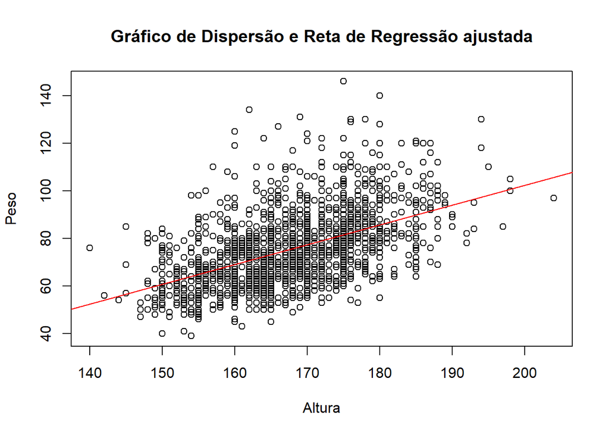

A reta de regressão estimada é:

Peso = -64.23 + 0.83 X Altura

Em média, para cada aumento de 1cm na altura o peso aumenta em 0.83kg, O coeficiente de determinação é :

```
## [1] 25.4
```

Logo, cerca de 25.4% da variação do peso é devida a variação na altura.

## 2.5 Associação entre o consumo de algum produto do tabaco(P050) e frequência de consumo de bebida alcoólica(P027).

O foco desa análise é verificar como o comportamento da variável resposta Y (Consumo de bebida alcoólica) muda na presença da variável explicativa X (Consumo de tabaco). A hipótese inicial é de que pessoas fazem uso do tabaco diariamente também consumam bebida alcoólica.

Com a tabela de frequencias absolutas é possível observar que o maior número de pessoas que fumam diariamente tamém consomem bebida alcoólica uma vez ou mais por mês.

Frequencias Absolutas

|  | Não Consome Álcool | Consome Álcool < 1x/mês | Consome Álcool > 1x/mês |
| --- | --- | --- | --- |
| Fuma Diariamente | 59 | 29 | 119 |
| Fuma Menos que Diariamente | 3 | 0 | 19 |
| Não Fuma Atualmente | 698 | 200 | 454 |

Utilizando a tabela de frequencias relativas é possível observar que os valores em cada categoria da variável resposta não são os mesmos para os diferentes níveis da variável explicativa, sendo assim, as frequências relativas dos níveis de Y dependem dos níveis de X.

Frequencias Relativas

|  | Não Consome Álcool | Consome Álcool < 1x/mês | Consome Álcool > 1x/mês |
| --- | --- | --- | --- |
| Fuma Diariamente | 0.04 | 0.02 | 0.08 |
| Fuma Menos que Diariamente | 0.00 | 0.00 | 0.01 |
| Não Fuma Atualmente | 0.44 | 0.13 | 0.29 |

Para responder se existe relação de dependencia entre o consumo de tabaco e o consumo de bebida alcoólica verifica-se a distribuição da variável resposta condicionada à variável explicativa.

```
##                     Não Bebe Álcool  Bebe<1x/mês  Bebe>1x/mês Sum
## Fuma Diariamente                0.29        0.14         0.57   1
## Fuma < 1x/dia                   0.14        0.00         0.86   1
## Não Fuma Atualmente             0.52        0.15         0.34   1
##                                 0.48        0.14         0.37   1
```

Se o consumo de tabaco não influenciasse no consumo de bebida alcoólica, esperaríamos ver as proporções da ultima linha linha da tabela para os níves da variável explicativa. Também é possível verificar graficamente.

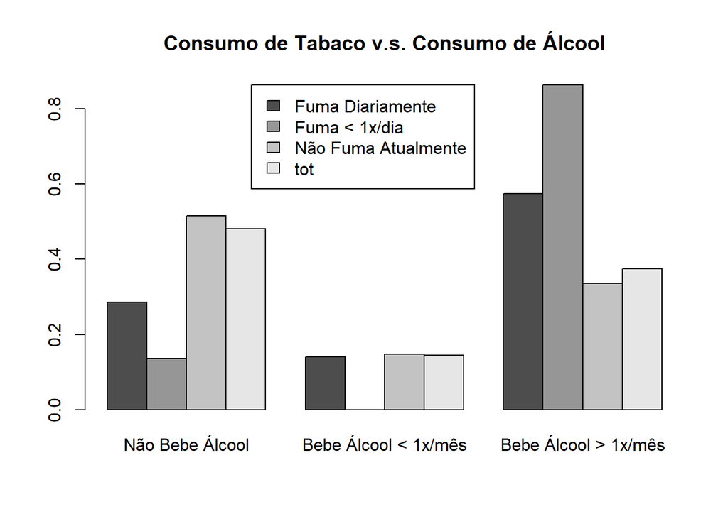

Através do teste Qui-quadrado é possível rejeitar a hipótese H0 (de que as variáveis são independendes), uma vez que o valor de p é menor do que 0,05, aceitando então a hipótese de associação entre as variáveis.

```
##
##  Pearson's Chi-squared test
##
## data:  qui
## X-squared = 70.442, df = 4, p-value = 0.00000000000001831
```

Em vista dos argumentos apresentados, configura-se como verdadeira a hipótese inicial dessa análise, de fato pessoas que fazem uso diário do tabaco, em geral, consomem (uma vez ou mais por mês) bebidas alcoólicas.

# 3 Códigos

```r
load("PNS2019_ESTCOMPUF.RData")
df_GO <- pns2019_uf_52
rm(list = setdiff(ls(),'df_GO'))
options(scipen = 999)

# QUESTÃO 1
names(df_GO)[names(df_GO) == 'V0026'] <- 'situ_censi'
names(df_GO)[names(df_GO) == 'A01901'] <- 'internet'
situ_censi <- factor(df_GO$situ_censi, levels = c('1','2'),
                     labels = c('Urbano','Rural'))
internet <- factor(df_GO$internet, levels = c('1','2'),
                   labels = c('Com Internet','Sem Internet'))
library(knitr)
kable(table(situ_censi, internet), caption = 'Frequencias absolutas')

kable(prop.table(table(situ_censi, internet)),
      digits = 2,
      caption = 'Frequencias Relativas')

round(rbind(addmargins(prop.table(table( situ_censi, internet),1), 2),
            addmargins(prop.table(table( internet) ))), 2)
a <- prop.table(table( situ_censi, internet), 1)
tot <- prop.table(table( internet) )
grafico_1 <- barplot(rbind(a,tot), beside=TRUE, legend=TRUE ,
                     main="Proporções de Situação Censitária v.s. Acesso à Internet")
qui <- table(situ_censi,internet)
chisq.test(qui)

#QUESTÃO 2

names(df_GO)[names(df_GO)=='N001'] <- 'saude'
names(df_GO)[names(df_GO)=='P034'] <- 'atividade_fisica'
saude <- factor(df_GO$saude, levels = c('1','2','3','4','5'),
                labels = c('Muito Boa','Boa','Regular','Ruim','Muito Ruim'))
atividade_fisica <- factor(df_GO$atividade_fisica, levels = c('1','2'),
                           labels = c('Praticantes','Não Praticantes'))
library(knitr)
kable(table(atividade_fisica, saude),
      caption = 'Frequencias Absolutas')
kable(prop.table(table(atividade_fisica, saude)),
      digits = 2,
      caption = 'Frequencias Relativas')

round(rbind(addmargins(prop.table(table( atividade_fisica, saude),1), 2),
            addmargins(prop.table(table(saude) ))), 2)
a <- prop.table(table( atividade_fisica, saude), 1)
tot <- prop.table(table( saude) )
grafico_1 <- barplot(rbind(a,tot), beside=TRUE, legend=TRUE ,
                     main="Atividade física v.s. Saúde")
qui <- table(atividade_fisica,saude)
chisq.test(qui)

# Questão 3

names(df_GO)[names(df_GO)=='E01602'] <- 'Renda'
names(df_GO)[names(df_GO)=='D001'] <- 'ler_escrever'
ler_escrever <- factor(df_GO$ler_escrever[!is.na(df_GO$Renda)], levels = c('1','2'),
                       labels = c('Simr','Não'))
renda <- df_GO$Renda[!is.na(df_GO$Renda)]
library(gplots)
plotmeans(renda~ler_escrever,xlab="Sabe ler e escrever", connect=F,
          ylab="Renda", main="Gráfico de Médias com IC")
anova1.lm <-anova(lm (renda~ ler_escrever))
anova1.lm <- anova1.lm[,c("Sum Sq", "Df", "Mean Sq", "F value", "Pr(>F)")]
names(anova1.lm) <- c( "S.Q", "G.L", "M.Q", "F", "P_val")
totals <- colSums(anova1.lm)
nice.anova.table <- as.data.frame(rbind(anova1.lm, totals),
                                  row.names = c("Entre", "Dentre", "Total"))
library(knitr)
options(knitr.kable.NA = '')
kable(nice.anova.table, format = "pandoc",
      caption = "Tabela Anova",
      digits = c(3, 0, 3, 4, 3), align = "rrrrr")
anova1 <-aov (renda~ ler_escrever)
qf(0.95,(length(anova1$residuals)-1-anova1$df.residual), anova1$df.residual)

# Questão 4

names(df_GO)[names(df_GO)=='P00104'] <- 'Peso'
names(df_GO)[names(df_GO)=='P00404'] <- 'Altura'
peso <- df_GO$Peso[!is.na(df_GO$Peso)]
altura <- df_GO$Altura[!is.na(df_GO$Altura)]
library(knitr)
kable( round(cor(peso , altura),3),
       caption="Coeficiente de correlação de Pearson")
ajuste <- lm (peso ~ altura)
sajuste <-summary(ajuste)
kable(round(sajuste$coefficients, 5),
      caption = "Resultado do Ajuste de Regressão Linear",
      digits = c(2, 3, 2, 4), align = "rrrr")
r <- round(sajuste$r.square*100,2)
plot( altura,peso, main='Gráfico de Dispersão e Reta de Regressão ajustada', xlab='Altura', ylab='Peso')
abline(lm(peso ~ altura ), col="red")
text(135, 200, bquote(R^2 == .(r)), cex=1.5)
ajuste <- lm (peso ~ altura)
sajuste <-summary(ajuste)
round(sajuste$r.square*100,2)

# Questão 5

names(df_GO)[names(df_GO)=='P027'] <- 'alcool'
names(df_GO)[names(df_GO)=='P050'] <- 'fuma'
alcool <- factor(df_GO$alcool, levels = c(1,2,3),
                 labels = c('Não Bebe ',' Bebe Menos de Uma Vez por Mês',' Bebe Uma Vez ou Mais por Mês'))
fuma <- factor(df_GO$fuma, levels = c(1,2,3),
               labels = c('Fuma Diariamente','Fuma Menos que Diariamente','Não Fuma Atualmente'))
library(knitr)
kable(table(fuma, alcool),
                  caption = 'Frequencias Absolutas')
kable(prop.table(table(fuma, alcool)),
                  digits = 2,
                  caption = 'Frequencias Relativas')
round(rbind(addmargins(prop.table(table( fuma, alcool),1), 2),
                      addmargins(prop.table(table( alcool) ))), 2)
a <- prop.table(table( fuma, alcool), 1)
tot <- prop.table(table( alcool) )
grafico_1 <- barplot(rbind(a,tot), beside=TRUE, legend=TRUE ,
                     main="Consumo de Tabaco v.s. Consumo de Álcool",
                     args.legend = list(x ='topright',inset=c(0.35,0)))
chisq.test(table(fuma,alcool))
```